# The Metagenome of Black Band Disease

Kendra

2026-11-19

# Assembly

Nanopore reads from the black band disease (BBD) metagenome were assembled using `Flye` in metagenome mode. Commands for this stage were run from the `flye/` directory.

A symbolic link to the BBD nanopore read file was added to ensure that the sequencing is accessed without duplicating the large input file:

```bash
ln -s /pvol/data/metagenome_assembly/bbd_0.1.fastq.gz .
```

Then, the `flye` assembly was run using the slurm shell script `run_flye_bbd.sh`, and the slurm job output was assessed:

```bash
sbatch run_flye_bbd.sh

ls -l bbd/assembly.fasta
```

The completed assembly (written by `Flye`) was saved to as `assembly.fasta`.

# Binning

Binning of the assembled contigs into genomes with MetaBAT 2. Commands for this step were run in `metabat/`.

To assess contig depth, contig names and their sequencing depths were extracted from the `Flye` assembly information file to create the depth file required for binning. The assembled contigs were also reorder to match the order of contigs in the depth file.

```bash
cat ../flye/bbd/assembly_info.txt  | grep -v '#' |

awk '{OFS="\t";print $1,$3}' > depths_bbd.txt

cat depths_bbd.txt | awk '{print $1}' | xargs samtools faidx ../flye/bbd/assembly.fasta > assembly_bbd_ordered.fasta
```

Finally, `metaBAT 2` was used to group the reordered contigs into bins based on sequence composition, and contig depth.

# Bin quality

Completeness and contamination of each bin were estimated with `CheckM`, and the most complete bins were chosen for further analysis. Commands for this step were run in `checkm/`.

Assembly contigs were sorted by sequence length to find the largest contig:

```bash
cat ../flye/bbd/assembly.fasta | bioawk -c fastx '{print length($seq),$name}' | sort -n
```

The largest contig in the bbd assembly was `contig_120`. This contig must be manually saved as an independent bin, in the same folder as the metabat bins, so that all the later steps treat it just like the other bins. Then, must copy all of the bins, including `contig_120` into the `bins_bbd` folder inside `CheckM`.

```bash
samtools faidx ../flye/bbd/assembly.fasta contig_120 > ../metabat/bins_bbd/contig_120.fa
cp ../metabat/bins_bbd/*.fa bins_bbd/
```

To assess quality with `CheckM`, the slurm script ‘run_checkm_bbd.sh’ was created and run:

```bash
sbatch run_checkm_bbd.sh
```

## Functional analysis of the BBD Metagenome

The purpose of binning is to sort the metagenome into species and strain within the black band disease community. They can also be leveraged to make inferences about metabolic processes present within a BBD lesion. Overall, the purpose of this functional analysis is to investigate (1) what taxonomic groups of microbes are present, and (2) what can they do in terms of genes and biochemical pathways present.

The results were checked within `checkm_results_bbd`

```bash
head checkm_results_bbd.txt
```

Marker lineage for top few bins: o__Cytophagales, p__Cyanobacteria, k__Bacteria, and o__Clostridiales.

Look further down the list:

```bash
head -n 20 checkm_results_bbd.txt
```

The analysis will focus on the most complete bins, i.e bins with a completeness greater than 15% (more likely to contain the majority of useful information on function within the bbd community). These bins will likely represent the most abundant taxa (and best assembled).

Extract bins with completeness greater than 15%:

```bash
cat checkm_results_bbd.txt | awk '$13>15'

cat checkm_results_bbd.txt | awk '$13>15{print $1}'

cat checkm_results_bbd.txt | awk '$13>15{print $1}' > bbd_topbins.txt
```

Saved output as `bbd_topbins.txt.`

# Taxonomy

GTDB-Tk was used to classify the bins retained after the CheckM assessment. Commands for this step were run from the `gtdbtk/` directory.

To prepare the genomes for classification, the list of bins retained during the CheckM assessment were used to copy the corresponding genome FASTA files into the `GTDB-Tk` input directory:

```bash
while read bin;do echo $bin;done < ../checkm/bbd_topbins.txt

while read bin;do echo "../metabat/bins_bbd/${bin}.fa";done < ../checkm/bbd_topbins.txt

while read bin;do cp "../metabat/bins_bbd/${bin}.fa" genomes;done < ../checkm/bbd_topbins.txt
```

`GTDB-Tk` was run using the slurm script `run_gtdbtk.sh` within `/gtdbtk`, and the output was confirmed and moved from the output directory into the main `gtdbtk/` directory for further analysis:

```bash
sbatch run_gtdbtk.sh

ls -l out/gtdbtk.bac120.summary.tsv

cp out/gtdbtk.bac120.summary.tsv .
```

# Gene annotation

Gene prediction and annotation of the most complete bins with Prokka. Commands for this step were run in `prokka/`.

The goal here is to assess the genes present within the genomes of bbd taxa within the mat to further our understanding of metabolic processes present. Prokka will identify the gene sequences and identify homologous genes with known functions.

To run `Prokka`, the bin `metabat.30` bin was chosen as a test:

```bash
cat ../checkm/bbd_topbins.txt

bin=metabat.30
prokka --cpus 2 --outdir $bin --prefix $bin  ../metabat/bins_bbd/${bin}.fa

ls metabat.30
```

Next, `Prokka` was run separately on each genome listed in `bbd_topbins.txt`. Each bin was given a seperate FASTA file, with its bin identifier used to name any outputs. This was done using the slurm script `run_prokka.sh` within `/prokka`. This produced predicted genes and associated functional information for each genome bin for further pathway analysis.

# Metabolic pathways

Metabolic pathways were inferred from the Prokka gene annotations using `MinPath`. `MinPath` uses annotated enzyme commission numbers to identify pathways that may explain genes detected within each bin. All commands for this step were run in the `minpath/` directory.

First, a single bin `metabat.30` was investigated:

```bash
head ../prokka/metabat.30/metabat.30.tsv
```

For input to minpath we only want to keep a unique ID for each gene (column 1) and its EC number (column 5). Must transform the tsv into this format using awk:

```bash
head ../prokka/metabat.30/metabat.30.tsv | awk -F '\t' '{print $1,$5}'
```

Here, we are using -F ’ to tell awk that our input is tab separated. We also want to filter the output to only include lines with an EC number, and ensure that the output is tab separated and we also need to remove the header line.

```bash
head ../prokka/metabat.30/metabat.30.tsv | awk -F '\t' '$5{print $1,$5}'

head ../prokka/metabat.30/metabat.30.tsv | awk -F '\t' '$5{OFS="\t";print $1,$5}' | grep -v '^locus'
```

Change head to cat to include all genes:

```bash
cat ../prokka/metabat.30/metabat.30.tsv | awk -F '\t' '$5{OFS="\t";print $1,$5}' | grep -v '^locus'
```

Send the output to a file so that it can be used as input to minpath:

```bash
cat ../prokka/metabat.30/metabat.30.tsv | awk -F '\t' '$5{OFS="\t";print $1,$5}' | grep -v '^locus' > metabat.30.ec
```

Run minpath on this file as follows;

```bash
minpath -ec metabat.30.ec -report metabat.30.ec.report -details metabat.30.ec.details
```

Look at output head:

```bash
head metabat.30.ec.report
```

Line 1: `path PWY-6012-1 any n/a naive 1 minpath 1 fam0 1 fam-found 1 name acyl carrier protein activation.` - `PWY-6012-1` is a pathway identifier in the metacyc database. - `native 1`: at least one gene from this pathway was found. - `MinPath 1`: minpath kept this pathway in its minimal set of pathways. If this says `minpath 0` then minpath decided that the genes found are better explained by other pathways, so the evidence for this one is weak - `fam0 1`: one gene involved in this path - `fam-found 1`: one gene family from the pathway in this genome - `name acyl carrier protein activation`: pathway name

Next, the Prokka annoation was filtered to retain the gene identifier and EC for all bins (required for MinPath).

```bash
while read bin;do
  cat ../prokka/$bin/${bin}.tsv | awk -F '\t' '$5{printf("%s\t%s\n", $1,$5)}' | grep -v '^locus' > ${bin}.ec
done < ../checkm/bbd_topbins.txt

while read bin;do
  minpath -ec ${bin}.ec -report ${bin}.ec.report -details ${bin}.ec.details
done < ../checkm/bbd_topbins.txt
```

The output is large, but the focus is on two pathways. The first pathway of interest is `PWY-101`, which includes the essential components of photosynthesis that occur in light, Photosystem I and Photosystem II.

```bash
grep 'PWY-101' *.ec.report
```

Detection of the photosynthesis light-reaction pathway (PWY-101) across the unbinned contig and metagenome-assembled genome (MAG) bins.

| Bin / contig | Pathway | Naive | MinPath | Families expected | Families found |
| --- | --- | --- | --- | --- | --- |
| contig_120 | PWY-101 | 1 | 0 | 4 | 1 |
| metabat.15 | PWY-101 | 1 | 1 | 4 | 1 |
| metabat.41 | PWY-101 | 1 | 0 | 4 | 1 |
| metabat.42 | PWY-101 | 1 | 1 | 4 | 4 |

These results show that at least 4 bins or contigs contained at least one of the expected gene families from the `PWY-101 pathway`. `metabat.42` had all four familiess (the complete pathway), while the other three had one of four. MinPath retained the pathway for only `metabat.15` and `metabat.42`.

For taxonomic identification, the `gtdbtk` classification table was cross referenced to determine the taxonomy of the bins containing the `PWY-101 pathway`:

```bash
grep 'contig_120' ../gtdbtk/gtdbtk.bac120.summary.tsv
grep 'metabat.15' ../gtdbtk/gtdbtk.bac120.summary.tsv
grep 'metabat.41' ../gtdbtk/gtdbtk.bac120.summary.tsv
grep 'metabat.42' ../gtdbtk/gtdbtk.bac120.summary.tsv
```

Taxonomic classification and detection of the PWY-101 photosynthesis light-reaction pathway across bins.

| Bin | Phylum | Class | Family | Taxon | Genes detected | MinPath |
| --- | --- | --- | --- | --- | --- | --- |
| contig_120 | Bacteroidota | Bacteroidia | Bernardetiaceae | UBA2561 sp002340355 | 1/4 | 0 |
| metabat.15 | Firmicutes_A | Clostridia | Vallitaleaceae | No genus or species assigned | 1/4 | 1 |
| metabat.41 | Desulfobacterota | Desulfobacteria | Desulforegulaceae | No genus or species assigned | 1/4 | 0 |
| metabat.42 | Cyanobacteria | Cyanobacteriia | Desertifilaceae | Roseofilum reptotaenium_A | 4/4 | 1 |

This process was repeated for the second path `PWY-5360`, a superpathway of tetrathionate reduction which includes enzymes required to reduce sulfite to hydrogen sulfide:

```bash
grep 'PWY-5360' *.ec.report
```

Detection of the superpathway of tetrathionate reduction (PWY-5360) across metagenome-assembled genome (MAG) bins.

| Bin | Pathway | Naive | MinPath | Families expected | Families found |
| --- | --- | --- | --- | --- | --- |
| metabat.12 | PWY-5360 | 1 | 0 | 3 | 1 |

One bin, `metabat.12` contained at least one gene from the `PWY-5360` pathway. The pathway is detected by the naive method (`naive = 1`) but not retained by MinPath, so these results do not support a complete tetrathionate-reduction pathway in this bin.

Cross reference the results with `gtdbtk` to see taxonomy:

```bash
grep 'metabat.12' ../gtdbtk/gtdbtk.bac120.summary.tsv
```

Taxonomic classification and detection of the PWY-5360 superpathway of tetrathionate reduction.

| Bin | Phylum | Class | Family | Taxon | Genes detected | MinPath |
| --- | --- | --- | --- | --- | --- | --- |
| metabat.12 | Campylobacterota | Campylobacteria | Arcobacteraceae | Halarcobacter sp. | 1/3 | 0 |

`metabat.12` corresponds to the order Campylobacterales and family Arcobacteraceae, and was classified to the genus Halarcobacter. However the evidence for this was weak; only 1/3 of the expected gene families were detected and MinPath did not retain the pathway.

# Data clean-up and visualization

### Assembly summary

Summary statistics were calculated from the final black band disease (BBD) metagenome assembly generated with Flye. These metrics describe the overall size and contiguity of the assembly:

```r
assembly <- readDNAStringSet("flye/bbd/assembly.fasta")

contig_lengths <- width(assembly)
sorted_lengths <- sort(contig_lengths, decreasing = TRUE)

cumulative_length <- cumsum(sorted_lengths)

n50 <- sorted_lengths[
  which(cumulative_length >= sum(sorted_lengths) / 2)[1]
]

assembly_table <- tibble(
  Metric = c(
    "Total assembly length",
    "Number of contigs",
    "N50",
    "Longest contig",
    "Mean contig length",
    "Median contig length"
  ),
  Value = c(
    paste0(round(sum(contig_lengths) / 1e6, 2), " Mb"),
    format(length(contig_lengths), big.mark = ","),
    paste0(format(n50, big.mark = ","), " bp"),
    paste0(format(max(contig_lengths), big.mark = ","), " bp"),
    paste0(format(round(mean(contig_lengths)), big.mark = ","), " bp"),
    paste0(format(round(median(contig_lengths)), big.mark = ","), " bp")
  )
)

kable(
  assembly_table,
  caption = "Table 1. Summary statistics for the BBD metagenome assembly generated with Flye.",
  align = c("l", "r")
)
```

Table 1. Summary statistics for the BBD metagenome assembly generated with Flye.

| Metric | Value |
| --- | --- |
| Total assembly length | 66.6 Mb |
| Number of contigs | 7,974 |
| N50 | 13,007 bp |
| Longest contig | 4,706,701 bp |
| Mean contig length | 8,352 bp |
| Median contig length | 3,985 bp |

### GC content

GC content was calculated for each assembled contig to describe variation in nucleotide composition across the metagenome:

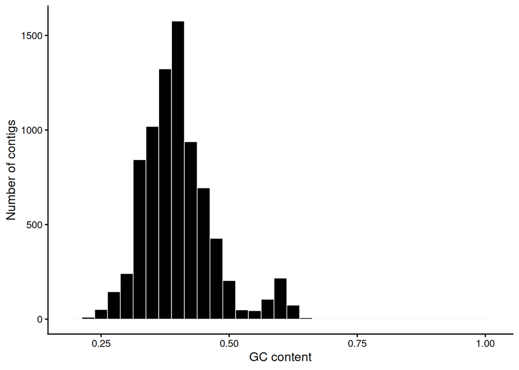

```r
gc_content <- letterFrequency(
  assembly,
  letters = c("G", "C")
)

gc_df <- tibble(
  GC = rowSums(gc_content) / width(assembly)
)

figure1 <- ggplot(gc_df, aes(x = GC)) +
  geom_histogram(
    binwidth = 0.025,
    fill = "black",
    colour = "#f9f9f6",
    linewidth = 0.3
  ) +
  labs(
    x = "GC content",
    y = "Number of contigs"
  ) +
  theme_classic(base_size = 12) +
  theme(
    panel.background = element_rect(fill = "transparent", colour = NA),
    plot.background = element_rect(fill = "transparent", colour = NA),
    axis.text = element_text(colour = "black"),
    axis.title = element_text(colour = "black")
  )

print(figure1)
```

Figure 1. Distribution of GC content among contigs in the BBD metagenome assembly.

### Genome quality and taxonomic classification

Genome-bin completeness and contamination were obtained from CheckM, while taxonomic classifications were obtained from GTDB-Tk. These results were combined to identify the major genome components recovered from the BBD metagenome:

```r
gtdbtk <- read_tsv(
  "gtdbtk/gtdbtk.bac120.summary.tsv",
  show_col_types = FALSE
)

gtdbtk_taxonomy <- gtdbtk |>
  separate_wider_delim(
    classification,
    delim = ";",
    names = c(
      "domain",
      "phylum",
      "class",
      "order",
      "family",
      "genus",
      "species"
    )
  ) |>
  mutate(
    across(
      c(domain, phylum, class, order, family, genus, species),
      ~ str_remove(.x, "^[a-z]__")
    )
  ) |>
  select(
    user_genome,
    domain,
    phylum,
    class,
    order,
    family,
    genus,
    species
  )
```

```r
checkm_lines <- readLines(
  "checkm/checkm_results_bbd.txt"
)

checkm_lines <- checkm_lines[
  grepl(
    "^(contig_|metabat\\.)",
    trimws(checkm_lines)
  )
]

checkm_split <- strsplit(
  trimws(checkm_lines),
  "\\s+"
)

checkm_df <- do.call(
  rbind,
  lapply(checkm_split, function(x) {
    data.frame(
      bin = x[1],
      lineage = x[2],
      completeness = as.numeric(x[13]),
      contamination = as.numeric(x[14])
    )
  })
)
```

```r
genome_summary <- checkm_df |>
  left_join(
    gtdbtk_taxonomy,
    by = c("bin" = "user_genome")
  ) |>
  mutate(
    taxon = case_when(
      !is.na(species) & species != "" ~ species,
      !is.na(genus) & genus != "" ~ paste0(genus, " sp."),
      !is.na(family) & family != "" ~ family,
      !is.na(order) & order != "" ~ order,
      !is.na(class) & class != "" ~ class,
      !is.na(phylum) & phylum != "" ~ phylum,
      TRUE ~ "Unclassified"
    ),
    taxon_label = paste0(taxon, " (", bin, ")")
  )
```

#### Genome completeness

Only genome bins with greater than 15% estimated completeness, which were retained for downstream taxonomic and functional analysis, are shown.

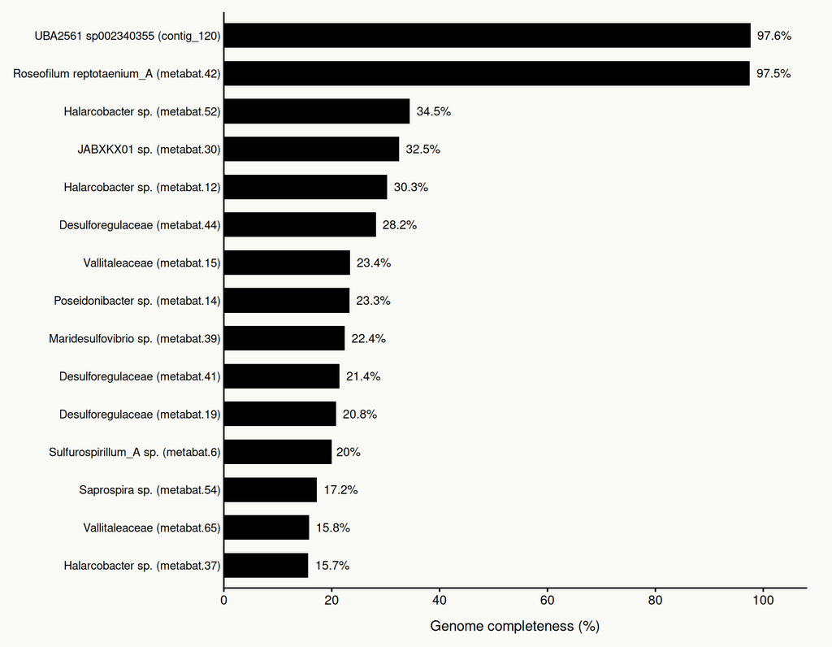

```r
genome_top <- genome_summary |>
  filter(completeness > 15) |>
  arrange(completeness)

figure2 <- ggplot(
  genome_top,
  aes(
    x = completeness,
    y = reorder(taxon_label, completeness)
  )
) +
  geom_col(
    fill = "black",
    width = 0.65
  ) +
  geom_text(
    aes(label = paste0(round(completeness, 1), "%")),
    hjust = -0.2,
    size = 3.3,
    colour = "black"
  ) +
  scale_x_continuous(
    limits = c(0, 108),
    breaks = seq(0, 100, 20),
    expand = expansion(mult = c(0, 0))
  ) +
  labs(
    x = "Genome completeness (%)",
    y = NULL
  ) +
  theme_classic(base_size = 12) +
  theme(
    # Match ePortfolio background
    plot.background = element_rect(
      fill = "#f9f9f6",
      colour = NA
    ),
    panel.background = element_rect(
      fill = "#f9f9f6",
      colour = NA
    ),

    # Clean typography
    axis.text.x = element_text(
      colour = "black",
      size = 10
    ),
    axis.text.y = element_text(
      colour = "black",
      size = 9
    ),
    axis.title.x = element_text(
      colour = "black",
      size = 11,
      margin = margin(t = 10)
    ),

    # Clean spacing
    axis.ticks.y = element_blank(),
    plot.margin = margin(10, 20, 10, 10)
  )

print(figure2)
```

Figure 2. Estimated completeness of genome bins of the BBD metagenome. Taxonomic labels represent the lowest classification assigned by GTDB-Tk. Only bins with >15% estimated completeness are shown.

### Major genome components

```r
taxonomy_table <- genome_top |>
  arrange(desc(completeness)) |>
  transmute(
    Bin = bin,
    Taxon = taxon,
    Phylum = phylum,
    `Completeness (%)` = round(completeness, 2),
    `Contamination (%)` = round(contamination, 2)
  )

kable(
  taxonomy_table,
  caption = "Table 2. Quality and taxonomic classification of genome bins",
  align = c("l", "l", "l", "r", "r")
)
```

Table 2. Quality and taxonomic classification of genome bins

| Bin | Taxon | Phylum | Completeness (%) | Contamination (%) |
| --- | --- | --- | --- | --- |
| contig_120 | UBA2561 sp002340355 | Bacteroidota | 97.62 | 1.64 |
| metabat.42 | Roseofilum reptotaenium_A | Cyanobacteria | 97.50 | 0.67 |
| metabat.52 | Halarcobacter sp. | Campylobacterota | 34.48 | 0.00 |
| metabat.30 | JABXKX01 sp. | Firmicutes_A | 32.51 | 1.77 |
| metabat.12 | Halarcobacter sp. | Campylobacterota | 30.28 | 0.00 |
| metabat.44 | Desulforegulaceae | Desulfobacterota | 28.18 | 0.13 |
| metabat.15 | Vallitaleaceae | Firmicutes_A | 23.38 | 0.00 |
| metabat.14 | Poseidonibacter sp. | Campylobacterota | 23.28 | 0.00 |
| metabat.39 | Maridesulfovibrio sp. | Desulfobacterota_I | 22.41 | 0.00 |
| metabat.41 | Desulforegulaceae | Desulfobacterota | 21.43 | 0.00 |
| metabat.19 | Desulforegulaceae | Desulfobacterota | 20.79 | 0.00 |
| metabat.6 | Sulfurospirillum_A sp. | Campylobacterota | 19.98 | 0.00 |
| metabat.54 | Saprospira sp. | Bacteroidota | 17.24 | 0.00 |
| metabat.65 | Vallitaleaceae | Firmicutes_A | 15.79 | 0.00 |
| metabat.37 | Halarcobacter sp. | Campylobacterota | 15.67 | 0.00 |

## Gene annotation

```r
bins <- readLines(
  "checkm/bbd_topbins.txt"
)

prokka_all <- map_dfr(
  bins,
  function(bin) {
    read_tsv(
      paste0(
        "prokka/",
        bin,
        "/",
        bin,
        ".tsv"
      ),
      show_col_types = FALSE
    ) |>
      mutate(bin = bin)
  }
)

total_features <- nrow(prokka_all)

genes_with_ec <- prokka_all |>
  filter(
    !is.na(EC_number),
    EC_number != ""
  ) |>
  nrow()

ec_percent <- (
  genes_with_ec /
  total_features
) * 100

prokka_summary <- tibble(
  Metric = c(
    "Features annotated by Prokka",
    "Features assigned an EC number",
    "Features with an EC assignment"
  ),
  Value = c(
    format(total_features, big.mark = ","),
    format(genes_with_ec, big.mark = ","),
    paste0(round(ec_percent, 1), "%")
  )
)

kable(
  prokka_summary,
  align = c("l", "r")
)
```

| Metric | Value |
| --- | --- |
| Features annotated by Prokka | 20,474 |
| Features assigned an EC number | 5,244 |
| Features with an EC assignment | 25.6% |

## Metabolic pathway analysis

```r
pathway_table <- tribble(
  ~Bin, ~Taxon, ~Pathway, ~`Families detected`, ~MinPath,
  "contig_120", "UBA2561 sp002340355", "PWY-101", "1/4", 0,
  "metabat.15", "Vallitaleaceae", "PWY-101", "1/4", 1,
  "metabat.41", "Desulforegulaceae", "PWY-101", "1/4", 0,
  "metabat.42", "Roseofilum reptotaenium_A", "PWY-101", "4/4", 1,
  "metabat.12", "Halarcobacter sp.", "PWY-5360", "1/3", 0
)

kable(
  pathway_table,
  caption = "Table 3. Detection of selected metabolic pathways within genome bins from the BBD metagenome.",
  align = c("l", "l", "l", "c", "c")
)
```

Table 3. Detection of selected metabolic pathways within genome bins from the BBD metagenome.

| Bin | Taxon | Pathway | Families detected | MinPath |
| --- | --- | --- | --- | --- |
| contig_120 | UBA2561 sp002340355 | PWY-101 | 1/4 | 0 |
| metabat.15 | Vallitaleaceae | PWY-101 | 1/4 | 1 |
| metabat.41 | Desulforegulaceae | PWY-101 | 1/4 | 0 |
| metabat.42 | Roseofilum reptotaenium_A | PWY-101 | 4/4 | 1 |
| metabat.12 | Halarcobacter sp. | PWY-5360 | 1/3 | 0 |